# 9_Matplotlib y Seaborn

PAO25_25_02_Python_Datatype

July 04, 2026

[figure not shown]

[figure not shown]

**Docente:** Elvis Pachacama

**Estudiante:** Dilan Salazar

**Repositorio:** [Machine Learning 2026](https://github.com/Dashmp/MachineLearning.git)

# Representacion grafica

- matplotlib basico (plot, legend, decoradores y anotaciones, grabar)
- dibujo con pandas (tipos de graficos)
- intro a seaborn https://seaborn.pydata.org/tutorial.html

# Referencias

- https://plotdb.com/
- https://plotnine.org/
- https://d3js.org/
- https://plot.ly/python/
- https://bokeh.org/
- https://shiny.rstudio.com/gallery/
- https://www.tableau.com/es-es

# 1 matplotlib

- Librería estándar de representación gráfica
- Low level: fácil de usar, difícil de dominar
- Control
- Gráficos y diagramas

## 1.0.1 Elementos de visualización

- Gráfico. Tipo de representación dentro de una subfigura o figura. Existen gran cantidad de tipos de gráficos: barras, líneas, tarta…
- Subfigura. Representación dentro de una figura.
- Figura. Marco donde se representan de manera conjunta una visualización. Se caracterizan por tener un título general y suele tener una descripción así como una fuente o referencia

```python
# importar matplotlib
import matplotlib.pyplot as plt
```

```python
import numpy as np
import pandas as pd
```

- ‘plot(data)’ para crear un gráfico con ‘data’
- ‘show()’ para mostrarlo

```python
 %matplotlib --list
```

[output not shown]

```python
# magic command para visualizar gráficos en jupyter en modo no interactivo
%matplotlib inline
```

```
array([[39, 81, 87],
       [63, 65, 93],
       [38, 61, 75]], dtype=int32)
```

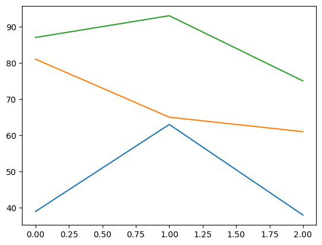

```python
data = np.random.randint(100,size=(3,3))
display(data)
plt.plot(data) # creación del gráfico
plt.show() # comando que muestra los gráficos creados hasta el momento
```

```python
 # activar modo interactivo
%matplotlib notebook
plt.ioff() # evitar que se sobreescriban los gráficos
%matplotlib inline
```

```
[75 76 77 78 79 80 81 82 83 84 85 86 87 88 89 90 91 92 93 94 95 96 97 98
 99] [31 76 13 37 66 23 51 40 23  0  4 63 11 58 60 30 16 16 32 24 67 13 56 78
 23]
```

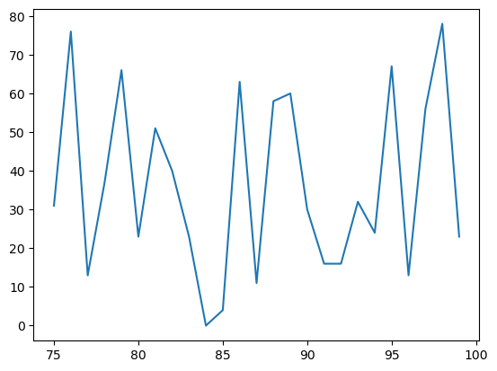

```python
# Se pueden especificar x e y por separado
x_data = np.arange(75, 100) # dimensiones!
y_data = np.random.randint(80,size=(25))
print(x_data,y_data)
if x_data.size == y_data.size:
    plt.plot(x_data, y_data)
    plt.show()
else:
    print(f"{x_data.size} no tienen las mismas dimensiones {y_data.size}")
```